# CITS5507 Project 2: Parallel Implementation and Discovery with different settings

Dayu Liu (24188516)

Semester 2, 2024

# Introduction

Matrix multiplication becomes increasingly expensive as the dimension size grows, particularly with sparse matrices, which contain mostly zero values and only a few non-zero elements. This results in unnecessary computations involving zeros, making the process inefficient in terms of both time and memory. In this research, we implemented a customized, simplified version of compressed matrix multiplication to address these inefficiencies. In the last project, we have explored how OpenMP enhances parallelization and improves the performance of compressed matrix multiplication by experimenting with different thread counts and parallelization strategies.

In Project 2, we aimed to integrate MPI on top of OpenMP and conducted a series of experiments with different approaches (Sequential, Pure OpenMP, Pure MPI, and MPI+OpenMP), along with various parameter combinations (number of nodes, processes per node, and threads per process). In the sequential experiments, we successfully determined which matrix density could handle the largest matrix size within a 10-minute time constraint. However, due to resource limitations on the Pawsey supercomputer, we later shifted our objective to focus on evaluating which configurations could complete the task most efficiently in the subsequent experiments.

All code implementations are included in the submitted zip file. Please refer to the comments in the `project2.sh` for instructions on how to run the code.

# Project Workflow

The project can be divided into two main parts:

**1. MPI Code Implementation:**  
In the first step, we started with the code from project1, we integrated implementations on MPI. The computing tasks are splitted evenly betwwen processes by distributes an equal range of rows to compute to each process. Barriers for collection are properly applied to make sure the result is right. Some other key changes include now we don’t write matrices to files when generating, instead they are saved after the experiment with `DEBUG` on to avoid taking account of time taken with heavy load File I/O operations. We also get rid of some unused functions on project 1’s ordinary `matrixMultiply()`.

**2. Parallel Experiments:**  
In the second step, we conducted experiments using varying node counts, process counts, and thread counts. The performance was monitored using Sequential, MPI, OpenMP, and MPI+OpenMP parallelization on the Pawsey supercomputer. Performance was evaluated based on execution time across different configurations. To conserve computing resources and address the usage shortage, our experiments focused on several key configurations rather than running them in bulk.

# Implementation

## Matrix Generation

The `generateMatrices()` function is responsible for creating matrices with a specified density of non-zero values. Each element in the matrix is assigned a value based on a random selection process that determines whether it will be a non-zero value, according to the specified density (percent).

This function generates two compressed matrices (values and indices) row by row. When a non-zero value is selected, a numerical value between 1 and 10 is assigned. These non-zero elements, along with their column indices, are stored in two corresponding compressed matrices.

## Compressed Matrix Multiplication Implementation

The function `compressedMatrixMultiply()` leverages both MPI and OpenMP to parallelize the multiplication of compressed matrices. It divides the main loop into smaller sub-loops for each process, assigning a specific range of rows between `start_row` and `end_row` to each process. These sub-loops are then parallelized using OpenMP’s `parallel for` directive, which distributes the work among a given number of threads.

For each element in the compressed matrix, its value and corresponding index are extracted. These values are then used to compute the product, and the result is added directly to the appropriate position in the result matrix.

## MPI and OpenMP flags

To make sure we can apply different combinations (Sequential, Pure OpenMP, Pure MPI and MPI+OpenMP) in a unified code base, flags for MPI `_MPI` and OpenMP `_OPENMP` are used to check if either are enabled, this is done by adding `-fopenmp` and customized `-D_MPI` flags when compiling the program, a hybrid combination would look like this: `mpicxx -fopenmp -D_MPI -o project2 project2.c`. After that we would use these flags to decide whether we need to initialize and utilize MPI/OpenMP functionalities during computation.

## Message broadcasting and barrier

Process 0 is responsible for generating the compressed matrices. After the generation is complete, the resulting matrices are flattened into 1-D arrays using the `flattenCompressedMatrix()` function, and the sizes of each row are recorded for MPI broadcasting. The data is then broadcast to all other processes using `MPI_Bcast()`. Each process receives the flattened array and reconstructs the original matrix using the `reconstructCompressedMatrix()` function, ensuring that all processes are working with the same data for parallel computation.

At the end of `compressedMatrixMultiply()`, a MPI barrier is applied to ensure that all processes have completed their computations. Once this synchronization is achieved, each process uses `MPI_Send()` to send its computed results to process 0. Process 0 then gathers these results using `MPI_Recv()`, consolidating the data to finalize the result.

# Experiments

## Experiment Setup

The following parameters were explored during the experiments:

**Experiment 1: Time estimation based on Matrix size and Non-zero Density**

In the first experiment, we would like to determine the impact of matrix size and non-zero element density (1%, 2%, and 5%) on execution time. Due to limited resources, the experiment was executed sequentially, though the insights gained should be applicable to other parallel configurations as well.

## Experiment 1

In the batch file (`project2.sh`), we started with a 10,000 x 10,000 matrix and doubled the size in each iteration to find a rough estimate of the largest matrix size that could be computed within 10 minutes. Once a rough estimate was obtained, we fine-tuned by incrementing the matrix size by 1000 in subsequent iterations to arrive at a more precise maximum size.

The executable is compiled once and reused across multiple iterations. An argument flag `--time=00:10:00` is applied to `srun` to ensure the program terminates if it exceeds the 10-minute time limit. Once the program has been terminated, we identified the last successful iteration and recorded its corresponding matrix size.

## Experiment 1 Result

For the 1% non-zero matrix, the maximum matrix size computed within the 10-minute constraint was 68,000 x 68,000, taking 588.622 seconds. For the 2% non-zero matrix, the maximum size dropped significantly to 46,000 x 46,000, taking 588.921 seconds, which is roughly 1/2.18 of the 1% matrix size. For the 5% non-zero matrix, the maximum size was reduced further to 26,000 x 26,000 (1/6.84 compared to the 1% matrix), taking 597.242 seconds.

The significant decline in matrix size can be attributed to the increased computational workload as matrix density rises. At 1% density, the abundance of zero elements allows the algorithm to bypass many operations, focusing only on non-zero values. However, as density increases to 2% and 5%, the proportion of non-zero elements grows, leaving fewer opportunities to skip computations. This leads to a surge in the number of necessary multiplications and additions, which directly impacts performance, resulting in longer processing times for denser matrices.

| Non-zero Density | Time Elapsed (s) | Matrix Size Achieved |
| --- | --- | --- |
| 1% | 588.622 | 68,000 x 68,000 |
| 2% | 588.921 | 46,000 x 46,000 |
| 5% | 597.242 | 26,000 x 26,000 |

> Some of the graphs below use logarithmic scales or uneven breaks on the X/Y axis to normalise the visual representation for easier comparison over a wide range of values.

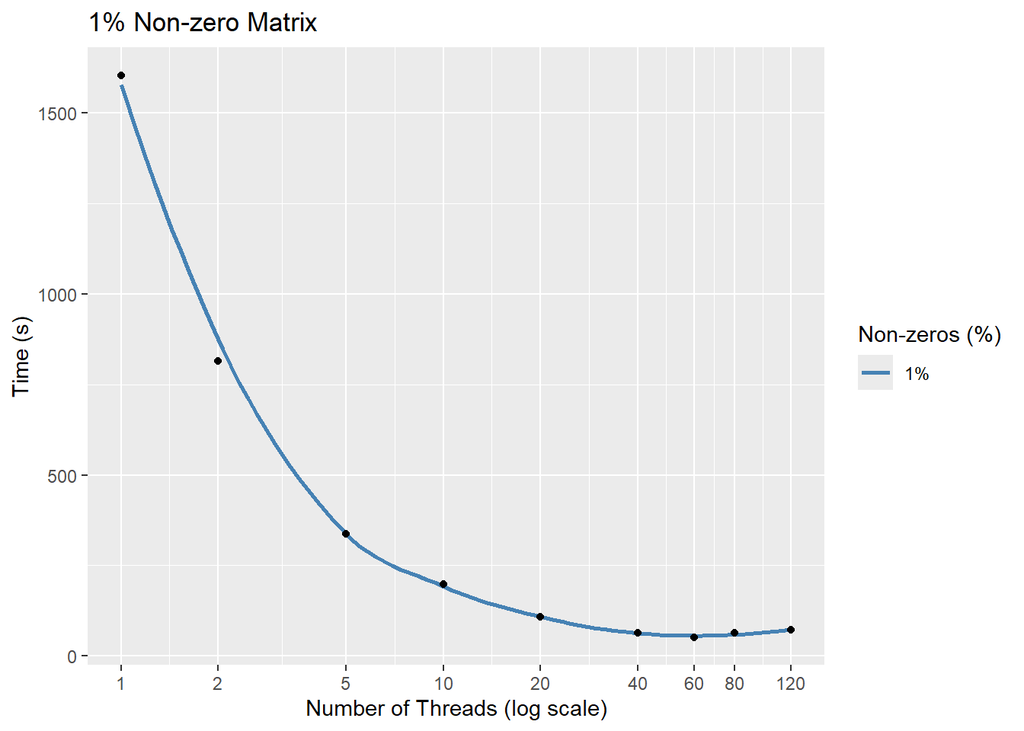

However, for the larger 2% and 5% non-zero matrices, optimal performance was achieved with 116-120 threads, the highest thread count in our experiments. The increased density of non-zero elements results in a larger computational workload, which can be more efficiently parallelized across more threads, reducing the overall time as more threads can handle the larger task in parallel.

Another plausible explanation is that for larger matrices like the 2% and 5% cases, the increased memory demands can hinder performance gains, thus requiring a higher thread count to achieve optimal performance. To address these memory-bound limitations, reducing memory consumption by using smaller data types, such as representing numerical values from 0-10 with char instead of int, might shift the local minimum execution time to a lower thread count.

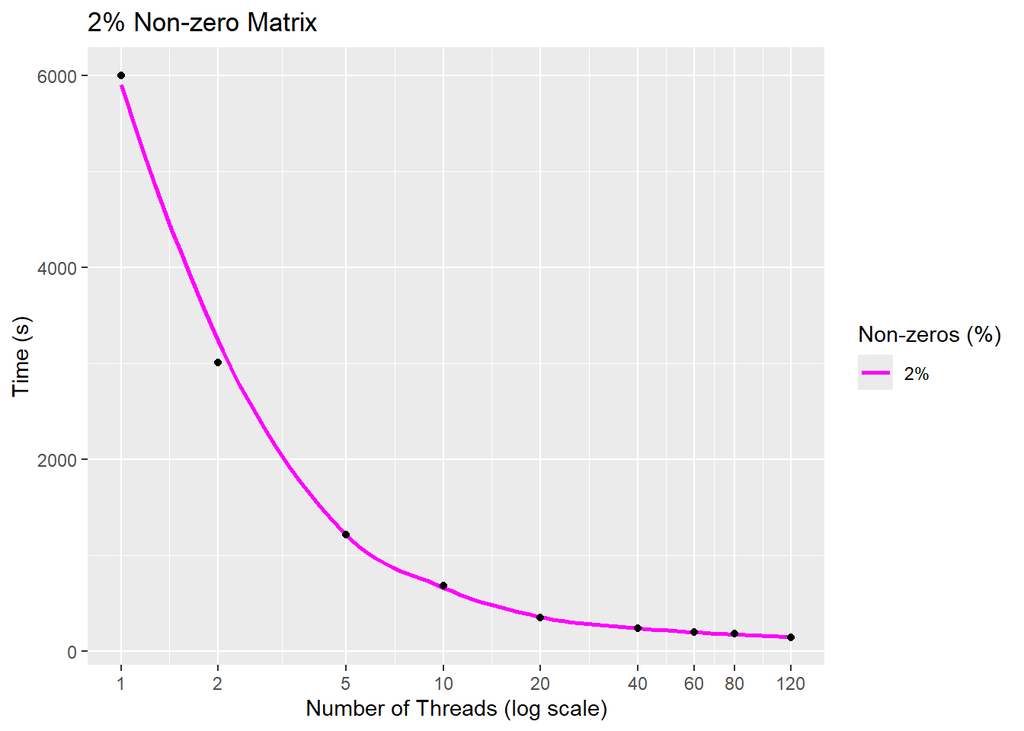

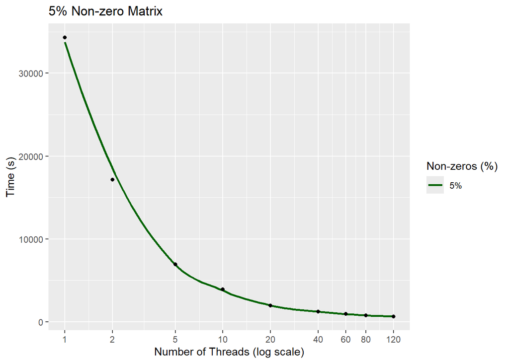

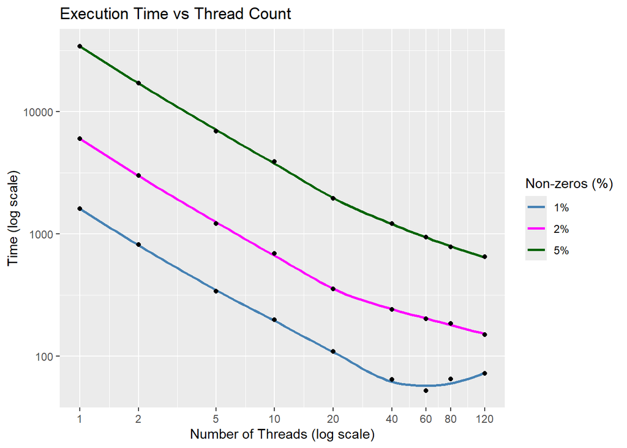

## Experiment 2

In the main program (`project1.c`), command-line arguments divide the workload by specifying different thread ranges and sparsity percentages for the compressed matrix multiplication task. This enables us to break the task into sub-tasks, each responsible for a specific range of threads on a certain set of matrices.

Matrices are first loaded from pre-generated files using the `loadMatrices()` function, which reads in compressed values and indices, to ensure every sub-task is working on the same set of data.

Once the matrices are loaded, the `compressedMatrixMultiply()` function is executed across varying thread counts, with OpenMP used to parallelize the operation. The execution time is recorded for each thread count using `omp_get_wtime()`, allowing us to evaluate the performance at different levels of parallelization.

Experiment 2 tested how different OpenMP scheduling strategies (static, dynamic, guided, and runtime) impact performance in matrix multiplication. The 1% matrix was selected because it provided optimal performance at 60 threads in previous experiments.

Given the large matrix size (100,000 x 100,000), chunk size likely plays a significant role in the efficiency of each scheduling type. Therefore, additional experiments were conducted with chunk sizes of 100, 200, and 500, which seemed suitable for parallelization on 60 threads. The default chunk size, indicated by 0, served as a baseline reference.

For runtime scheduling, which relies on the `OMP_SCHEDULE` environment variable, we couldn’t set its parameter explicitly, but it still provides a valuable comparison between different combinations.

## Experiment 2 result

At chunk size 0, which represents the default chunk size, the four scheduling strategies demonstrated distinct performance patterns. Static scheduling performed the worst among all, as its sensitivity to load imbalances caused slower performance compared to more adaptive strategies. Dynamic scheduling achieved the best performance, as it effectively minimized idle time by distributing smaller chunks of work to threads and ensuring balanced workloads. Runtime scheduling was the second fastest, likely due to the environment variables being well-optimized on Pawsey’s system. Guided scheduling, while not as fast as other candidates, performed slightly better than static, maintaining a rather balanced workload distribution.

> The static scheduling task with the default chunk size took longer in Experiment 2 compared to Experiment 1. This can be attributed to variations in individual node performance and Pawsey’s slower transfer speeds during the experiment on September 18th. To account for these inconsistencies, we reran the static scheduling with the default chunk size in Experiment 2 for a more reliable comparison.

| Scheduling Type | Time w/o Chunk size |
| --- | --- |
| static | 113.135 |
| dynamic | 61.9773 |
| guided | 101.167 |
| runtime | 89.1588 |

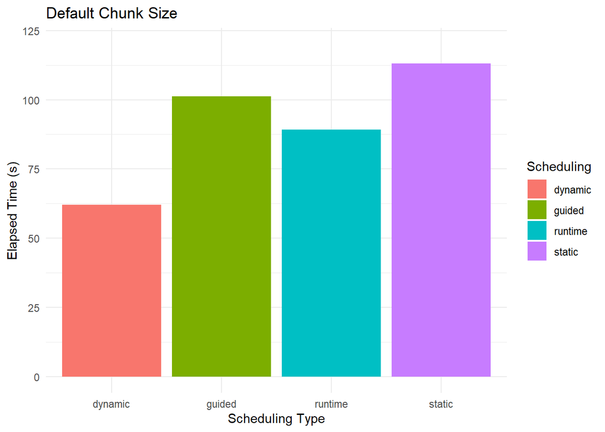

In our side quest, we observed that the benefits of a more adaptive strategy diminished as chunk sizes increased. In the dynamic strategy, performance dropped significantly with larger chunk sizes due to the inability to evenly distribute the workload across threads. The guided strategy, however, performed better with a chunk size of 100 compared to the default, suggesting that the default chunk size may not be well-suited for larger workloads like this.

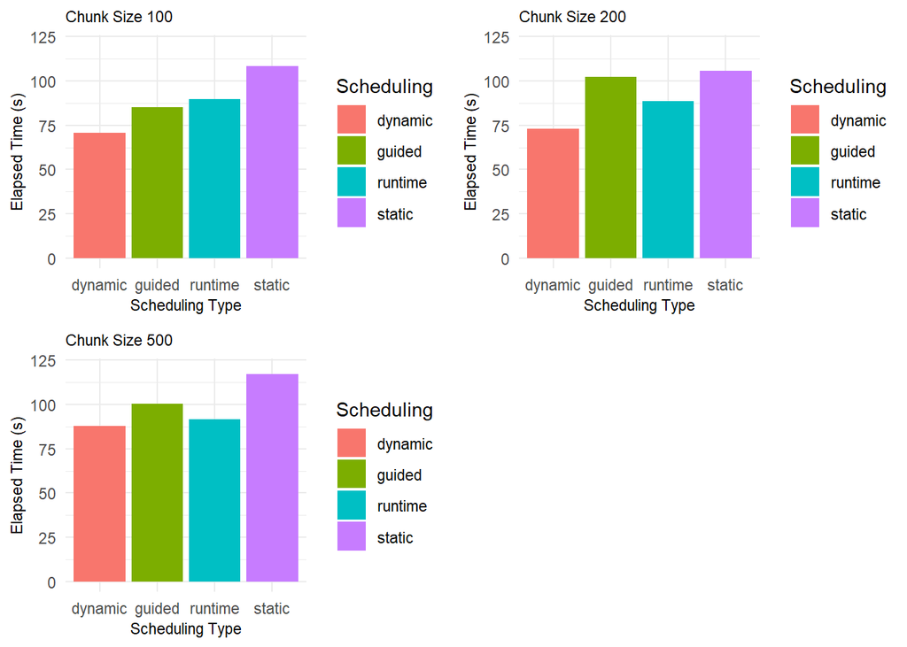